# GLM part 6: Logistic regression for binary outcomes

Nick Green, Kennesaw State University

November 23, 2021

# 1 Overview

This is one of several sections exploring some common GLM applications. For most of these applications we will work through two examples. First, an analysis of simulated data, and second, an analysis of a real dataset. Simulating a dataset suitable for an analysis is an excellent way to learn about the analysis method, because it helps you see the relationship between the data-generating process and the analysis.

This module explores GLMs for **binary outcomes**. Binary outcomes are results that take one of two values: survival vs. non-survival, presence vs. absence, reproduction vs. not-reproducing, and so on. These data are usually coded as 1 and 0: 1 when the event occurs, and 0 when the event does not. No other values are allowed. The standard technique for modeling binary outcomes is **logistic regression**. This name refers to a GLM with a binomial family and logit link function.

# 2 Logistic regression

Logistic regression is a technique for modeling the probability of a binary outcome: survival vs. death, reproductive vs. not reproductive, present vs. absent, etc. The response variable *Y* takes value 1 when the event occurs, and value 0 when the event does not occur. For each observation *i*, success occurs as the outcome of a Bernoulli trial with probability *p*<sub>i</sub>. The logit of *p*<sub>i</sub> (i.e., the logarithm of the odds that *Y* = 1) is modeled as a linear function of the predictor variables.

$$Y_i \sim Bernoulli\left(p_i\right)$$
$$logit\left(p_i\right)=\log{\left(\frac{p_i}{1-p_i}\right)}=\beta_0+\beta_1X_i$$

The inverse link function is the **logistic function**, which is also where the name “logistic regression” comes from:

$$logistic\left(x\right)=\frac{e^x}{1+e^x}$$

The linear predictor in logistic regression predicts the “log-odds” of an event occurring. The unit of the log-odds scale is the **logistic unit**, or **logit**. The logit link function is useful because it allows the outcome of a linear function–which can take on any real value–to be mapped smoothly to the natural domain of probabilities, the open interval (0, 1). A key consequence of this link function is that increasing the value of one of the predictor variables by 1 will scale the log-odds by a constant. That constant is the coefficient estimated for the predictor.

The logistic regression model was developed in the 1940s, decades before the GLM was first proposed. Part of the development of the idea of the GLM was recognizing that many previously known models were actually special cases of a more general model. In GLM terms, we say that logistic regression is a GLM with a binomial family and logit link function.

# 3 Example with simulated data

As with the other GLM applications, we’ll start by simulating a suitable dataset and analyzing it. The code below will execute the simulation. Remember to set the random number seed for reproducibility.

```r
set.seed(123)
n <- 30
x <- round(runif(n, 0, 12), 1)

# coefficients
beta0 <- -4
beta1 <- 0.8

# linear predictor
eta <- beta0 + beta1 * x

# logistic function (inverse link)
prob <- plogis(eta)

# draw y values (stochastic part)
y <- rbinom(n, 1, prob)

# assemble dataset
dat <- data.frame(x=x, y=y)

# take a look at the data:
head(dat)
```

```
##      x y
## 1  3.5 1
## 2  9.5 1
## 3  4.9 1
## 4 10.6 1
## 5 11.3 1
## 6  0.5 0
```

Unlike other sorts of regression problems, plotting *Y* vs. *X* isn’t very illuminating:

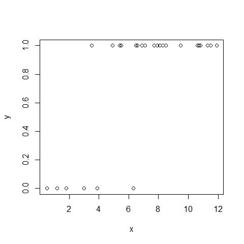

```r
plot(x, y)
```

If you have a lot of duplicate coordinates, it can be hard to get a sense of how many 0s and 1s are in the dataset. The scatterplot above is also a little silly because most of the *Y*-axis range is not occupied. We can use function `jitter()` to add some random noise to the *Y*-values; this will help us see what is going on.

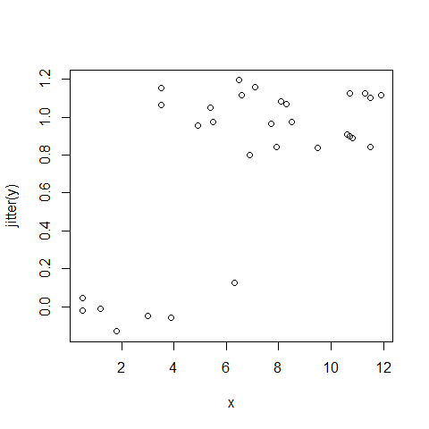

```r
plot(x, jitter(y))
```

Another way to explore binary data is with a boxplot. A boxplot can show whether *X* tends to be smaller or greater when *Y* = 1; this is sort of the reverse of the question we are really asking, but it helps us make sense of the data as we explore.

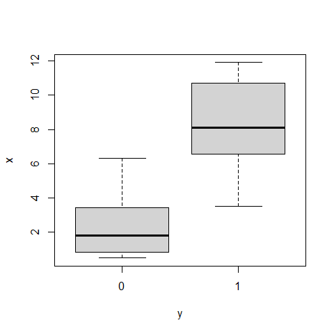

```r
boxplot(x~y)
```

The boxplot agrees with the scatterplot: *Y* seems more likely to occur at greater values of *X*. Making the boxplot horizontal makes the agreement more clear:

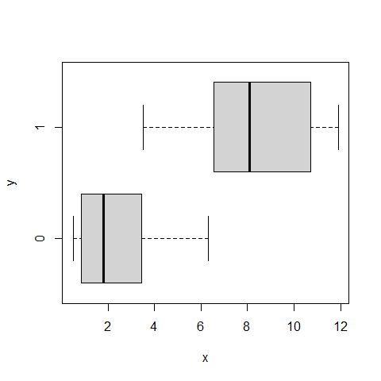

```r
boxplot(x~y, horizontal=TRUE)
```

Logistic regression is fit using the `glm()` function. By definition, logistic regression is a GLM with a binomial family and logit link function. You don’t need to specify the link function in R, as the binomial family uses the logit link function by default.

```r
mod1 <- glm(y~x, data=dat, family=binomial)
summary(mod1)
```

```
##
## Call:
## glm(formula = y ~ x, family = binomial, data = dat)
##
## Deviance Residuals:
##      Min        1Q    Median        3Q       Max
## -2.25927   0.02705   0.06648   0.29492   1.30865
##
## Coefficients:
##             Estimate Std. Error z value Pr(>|z|)
## (Intercept)  -3.7713     1.8349  -2.055   0.0399 *
## x             0.9909     0.4001   2.477   0.0133 *
## ---
## Signif. codes:  0 '***' 0.001 '**' 0.01 '*' 0.05 '.' 0.1 ' ' 1
##
## (Dispersion parameter for binomial family taken to be 1)
##
##     Null deviance: 32.596  on 29  degrees of freedom
## Residual deviance: 13.193  on 28  degrees of freedom
## AIC: 17.193
##
## Number of Fisher Scoring iterations: 7
```

The parameter estimates are pretty close to the correct values. We can calculate the pseudo-*R*<sup>2</sup> as usual:

```r
1-mod1$deviance/mod1$null.deviance
```

```
## [1] 0.5952722
```

The pseudo-*R*<sup>2</sup> is pretty good for only having 30 observations. But, you should probably consider using AUC instead of pseudo-*R*<sup>2</sup> (see below). The next step is to generate and plot the model predictions. For logistic regression models, predictions should be calculated on the link scale and back-transformed to get probabilities.

```r
# values for prediction
use.n <- 50
px <- seq(min(dat$x), max(dat$x), length=use.n)

# calculate predictions and 95% CI (link scale)
pred <- predict(mod1, newdata=data.frame(x=px),
                type="link", se.fit=TRUE)
mn <- pred$fit
lo <- qnorm(0.025, mn, pred$se.fit)
up <- qnorm(0.975, mn, pred$se.fit)

# inverse link function to get probabilities
mn <- mod1$family$linkinv(mn)
lo <- mod1$family$linkinv(lo)
up <- mod1$family$linkinv(up)
```

Now make the plot. The argument `xpd=NA` to `points()` makes sure that all points are plotted, even those that fall outside of the plot area. This is needed because `plot()` defines the plot area using the maximum *Y* value (1), but some of the jittered *Y* values will be <0 or > 1 and thus won’t get plotted. We’ll use a polygon instead of the usual lines to show the 95% CI of the predicted probability.

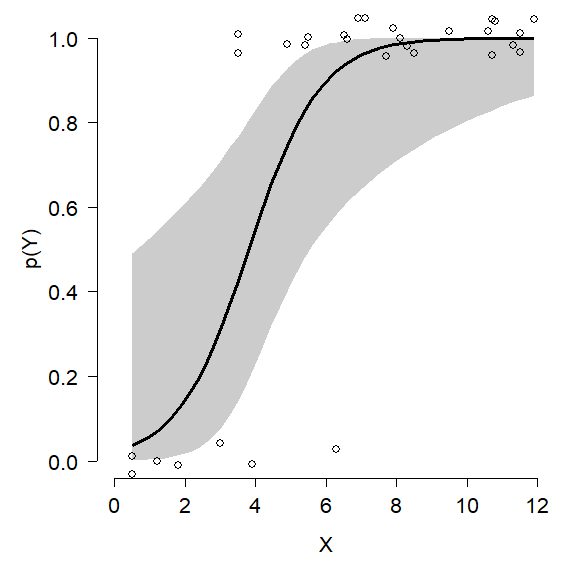

```r
par(mfrow=c(1,1), mar=c(5.1, 5.1, 1.1, 1.1),
    bty="n", las=1, lend=1, cex.axis=1.3,
    cex.lab=1.3)
plot(dat$x, dat$y, type="n", xlab="X",
     ylab="p(Y)", ylim=c(0, 1), xlim=c(0, 12))
polygon(x=c(px, rev(px)),
        y=c(lo, rev(up)), # REVerse either upper or lower
        border=NA, col="grey80")
points(px, mn, type="l", lwd=3)
points(dat$x, jitter(dat$y, amount=0.05),
       cex=1.1, xpd=NA)
```

# 4 Example with real data

Bubrig et al. (2020) studied the influence of bacteria on the emergence of nematodes (*Caenorhabditis elegans*) from their dormant state. *C*. *elegans* sometimes enter a dormant state called a **dauer** that permits larvae to survive long periods of adverse conditions and to disperse long distances by passive transportation. The figure below shows the place of the dauer state in the normal *C*. *elegans* life cycle (Bubrig et al. 2020). Previous work had shown that successful colonization of new habitats by *C*. *elegans* is heavily influenced by the nearby bacterial community. The authors investigated whether the bacterial community could affect the emergence of individual worms from their dormant state.

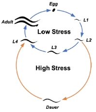

In their experiment, they inoculated plates with one of three strains of *C*. *elegans* and one of five species of bacteria (or no bacteria as a control). After some time, the plates were treated with a chemical known to kill worms not in the dauer stage. The researchers then surveyed the plates and recorded each dead worm (which had emerged) as 1 and each worm still in dauer state (i.e., not emerged) as 0.

Download the dataset bubrig_2020_data.csv and put it in your R working directory.

```r
in.name <- "bubrig_2020_data.csv"
dat <- read.csv(in.name, header=TRUE)
head(dat)
```

```
##   trial repl strain   treat     dose y   categ
## 1     1    1     N2 Control 418.3225 1 Control
## 2     1    1     N2 Control 418.3225 1 Control
## 3     1    2     N2 Control 418.3225 1 Control
## 4     1    3     N2 Control 418.3225 1 Control
## 5     1    3     N2 Control 418.3225 1 Control
## 6     1    3     N2 Control 418.3225 1 Control
```

We suspect that the response variable `y` is related to the predictors `strain` (of worm) and `treat` (“treatment” of bacteria). Both of these predictor variables are factors, so scatterplots won’t be very helpful. Instead, we can try some methods for visualizing categorical data. The function `mosaicplot()` produces a plot that partitions the observations by different combinations of factors[^1]:

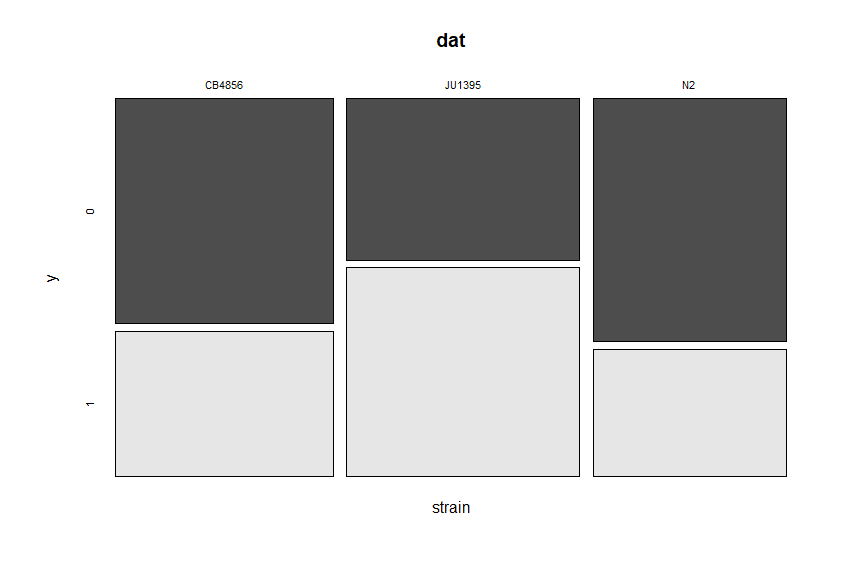

```r
mosaicplot(strain~y, data=dat, color=TRUE)
```

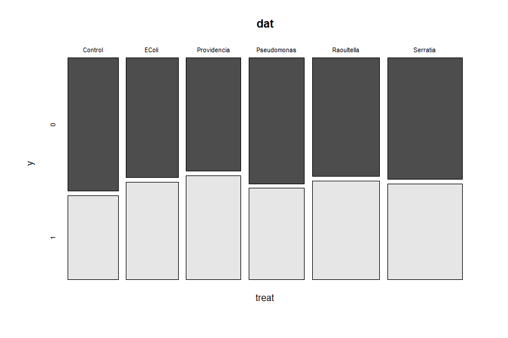

```r
mosaicplot(treat~y, data=dat, color=TRUE)
```

Observations can be split by an arbitrary number of factors:

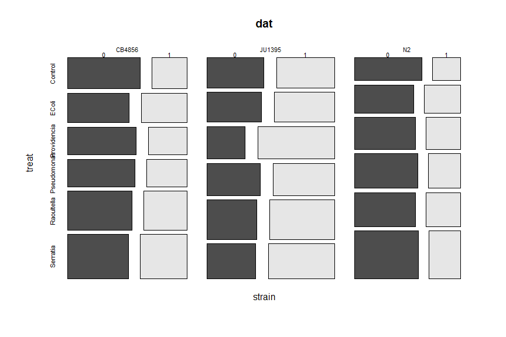

```r
mosaicplot(strain~treat+y, data=dat, color=TRUE)
```

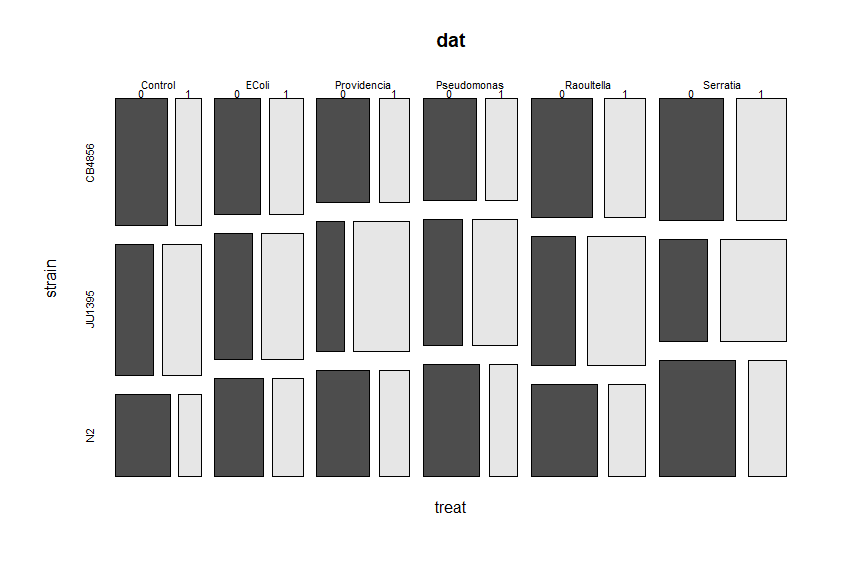

```r
mosaicplot(treat~strain+y, data=dat, color=TRUE)
```

As you might have guessed, **mosaic plots** are a graphical way of representing a **contingency table**. Mosaic plots are great tools for data exploration, but don’t often make it into publications because they use a great deal of space and ink relative to the amount of information they convey. The equivalent contingency tables can be seen with the commands below:

```r
ftable(y~strain, data=dat)
```

```
##        y    0    1
## strain
## CB4856   3925 2527
## JU1395   3007 3890
## N2       3755 1967
```

```r
ftable(y~treat, data=dat)
```

```
##             y    0    1
## treat
## Control       1662 1051
## EColi         1539 1254
## Providencia   1533 1408
## Pseudomonas   1735 1260
## Raoultella    1973 1639
## Serratia      2245 1772
```

```r
ftable(y~strain+treat, data=dat)
```

```
##                    y   0   1
## strain treat
## CB4856 Control       681 330
##        EColi         548 406
##        Providencia   571 324
##        Pseudomonas   559 337
##        Raoultella    752 506
##        Serratia      814 624
## JU1395 Control       518 530
##        EColi         490 541
##        Providencia   375 750
##        Pseudomonas   519 593
##        Raoultella    594 780
##        Serratia      511 696
## N2     Control       463 191
##        EColi         501 307
##        Providencia   587 334
##        Pseudomonas   657 330
##        Raoultella    627 353
##        Serratia      920 452
```

Because we have a binary response variable, our first option should be logistic regression. Notice that we still call this model logistic “regression” even though there are no continuous predictors. Another name might be a “Binomial ANOVA”, in the same way that a regular ANOVA is just a special case of linear models. Just as we did in the Poisson regression examples, we will fit several models with different predictors and compare their efficacy using information theoretic methods.

For this example, we’re going to define model formulas ahead of time and fit the models in a loop. This is because the code for each model differs only in one part, the formula. Having the formulas in a separate vector and the models in a list will also make it easier to construct the AIC table for model selection. To match the original analysis done by Bubrig et al. (2020), we should treat strain `N2` as the baseline. To do this, we need to re-specify the factor strain.

```r
# convert to factor if not already
class(dat$strain)
```

```
## [1] "character"
```

```r
# if "character", run next line:
dat$strain <- as.factor(dat$strain)
dat$strain <- relevel(dat$strain, ref="N2")
```

Now we define the model formulas and fit the models.

```r
# define some model formulas
forms <- c("y~strain", "y~treat",
           "y~strain+treat", "y~strain*treat")

# make a list to hold models
mlist <- vector("list", length(forms))

# fit models in a loop
for(i in 1:length(forms)){
    mlist[[i]] <- glm(forms[i], data=dat, family=binomial)
}
```

Constructing the AIC table is made easy; all we have to do is pull AIC values from the list. Compare this to the method in the [previous section](https://greenquanteco.github.io/05-glm-05-quasi_nb_glm.html), where we had to type out each model’s name.

```r
# construct AIC table
aicdf <- data.frame(mod=1:length(forms),
                    form=forms,
                    aic=sapply(mlist, AIC))

# calculate AIC weights
aicdf <- aicdf[order(aicdf$aic),]
aicdf$delta <- aicdf$aic - min(aicdf$aic)
aicdf$wt <- exp(-0.5*aicdf$delta)
aicdf$wt <- aicdf$wt/sum(aicdf$wt)
aicdf <- aicdf[order(-aicdf$wt),]
aicdf$cumsum <- cumsum(aicdf$wt)
aicdf
```

```
##   mod           form      aic     delta            wt cumsum
## 4   4 y~strain*treat 25356.38   0.00000  1.000000e+00      1
## 3   3 y~strain+treat 25400.32  43.93681  2.879002e-10      1
## 1   1       y~strain 25457.15 100.76847  1.313424e-22      1
## 2   2        y~treat 26114.37 757.98983 2.538633e-165      1
```

```r
summary(mlist[[aicdf$mod[1]]])
```

```
##
## Call:
## glm(formula = forms[i], family = binomial, data = dat)
##
## Deviance Residuals:
##    Min      1Q  Median      3Q     Max
## -1.482  -1.014  -0.894   1.168   1.569
##
## Coefficients:
##                               Estimate Std. Error z value Pr(>|z|)
## (Intercept)                   -0.88545    0.08600 -10.296  < 2e-16 ***
## strainCB4856                   0.16098    0.10906   1.476 0.139917
## strainJU1395                   0.90836    0.10589   8.578  < 2e-16 ***
## treatEColi                     0.39570    0.11247   3.518 0.000434 ***
## treatProvidencia               0.32157    0.10997   2.924 0.003453 **
## treatPseudomonas               0.19686    0.10931   1.801 0.071700 .
## treatRaoultella                0.31098    0.10873   2.860 0.004237 **
## treatSerratia                  0.17476    0.10342   1.690 0.091047 .
## strainCB4856:treatEColi        0.02885    0.14641   0.197 0.843775
## strainJU1395:treatEColi       -0.31958    0.14267  -2.240 0.025092 *
## strainCB4856:treatProvidencia -0.16375    0.14639  -1.119 0.263322
## strainJU1395:treatProvidencia  0.34868    0.14110   2.471 0.013471 *
## strainCB4856:treatPseudomonas  0.02154    0.14561   0.148 0.882395
## strainJU1395:treatPseudomonas -0.08647    0.13921  -0.621 0.534473
## strainCB4856:treatRaoultella   0.01729    0.14010   0.123 0.901753
## strainJU1395:treatRaoultella  -0.06146    0.13640  -0.451 0.652285
## strainCB4856:treatSerratia     0.28390    0.13426   2.115 0.034464 *
## strainJU1395:treatSerratia     0.11132    0.13381   0.832 0.405476
## ---
## Signif. codes:  0 '***' 0.001 '**' 0.01 '*' 0.05 '.' 0.1 ' ' 1
##
## (Dispersion parameter for binomial family taken to be 1)
##
##     Null deviance: 26159  on 19070  degrees of freedom
## Residual deviance: 25320  on 19053  degrees of freedom
## AIC: 25356
##
## Number of Fisher Scoring iterations: 4
```

In a typical ANOVA, the coefficients for each factor represent the difference in means from the baseline. In this logistic regression model, the coefficients represent differences in the log of the odds ratio. Recall that the link scale for logistic regression is the log of the odds ratio. The odds ratio of an event with probability *p* is $p/(1-p)$. In practical terms, this describes the relative likelihood of an event occurring. For example, if the odds ratio for treatment *A* vs. *control* is 1.8, then the event is 1.8 times more likely to occur in treatment group *A*. Alternatively, being in treatment *A* increases the probability of the event by a factor of 1.8. The SE of the coefficient can be used to estimate a 95% CI of the odds ratio.

```r
coefs <- summary(mlist[[4]])$coefficients
coefs
```

```
##                                  Estimate Std. Error     z value     Pr(>|z|)
## (Intercept)                   -0.88545363 0.08599663 -10.2963755 7.316629e-25
## strainCB4856                   0.16098397 0.10906031   1.4761005 1.399169e-01
## strainJU1395                   0.90835539 0.10589011   8.5782836 9.629926e-18
## treatEColi                     0.39569527 0.11246670   3.5183329 4.342673e-04
## treatProvidencia               0.32156980 0.10996822   2.9242066 3.453355e-03
## treatPseudomonas               0.19686226 0.10930596   1.8010204 7.169966e-02
## treatRaoultella                0.31097514 0.10873444   2.8599508 4.237067e-03
## treatSerratia                  0.17476214 0.10341550   1.6899028 9.104656e-02
## strainCB4856:treatEColi        0.02885225 0.14640819   0.1970672 8.437750e-01
## strainJU1395:treatEColi       -0.31958315 0.14267199  -2.2399852 2.509188e-02
## strainCB4856:treatProvidencia -0.16374584 0.14638809  -1.1185735 2.633221e-01
## strainJU1395:treatProvidencia  0.34867562 0.14110387   2.4710563 1.347146e-02
## strainCB4856:treatPseudomonas  0.02154085 0.14561178   0.1479334 8.823953e-01
## strainJU1395:treatPseudomonas -0.08647351 0.13920564  -0.6211926 5.344729e-01
## strainCB4856:treatRaoultella   0.01729485 0.14009989   0.1234466 9.017535e-01
## strainJU1395:treatRaoultella  -0.06146231 0.13640390  -0.4505905 6.522847e-01
## strainCB4856:treatSerratia     0.28389752 0.13425558   2.1146050 3.446363e-02
## strainJU1395:treatSerratia     0.11131617 0.13381251   0.8318816 4.054758e-01
```

Let’s interpret the terms from top to bottom. The `Intercept` term describes the expectation for an observation with all factors at their baseline values (strain = `N2`, treatment = `control`). We can translate this to a probability using the inverse logit function:

```r
plogis(coefs[1,1])
```

```
## [1] 0.2920489
```

So, an N2 worm in the control treatment has a 0.29 probability of emerging from dauer.

The next two coefficients, `strainCB4856` and `strainJU1395`, describe the odds ratios of animals from the other worm strains, in the control group. The odds ratios for emerging from dauer while being in one of those strains instead of the baseline strain are obtained by exponentiating the estimates.

```r
exp(coefs[2:3,1])
```

```
## strainCB4856 strainJU1395
##     1.174666     2.480240
```

This means that a CB4856 worm in the control treatment would be 1.17 times more likely to emerge than an N2 worm in the control group, and a JU1395 worm in the control treatment would be 2.48 times as likely to emerge as an N2 worm in the control group. The 95% CI for those odds ratios are:

```r
exp(coefs[2:3,1]-1.96*coefs[2:3,2])
```

```
## strainCB4856 strainJU1395
##    0.9485942    2.0153861
```

```r
exp(coefs[2:3,1]+1.96*coefs[2:3,2])
```

```
## strainCB4856 strainJU1395
##     1.454616     3.052314
```

So, within the control treatment, CB4856 worms are 1.17 times more likely to emerge, and we are 95% confident that the odds ratio is in the interval [0.948, 1.455].

The next set of coefficients, `treatEColi`, `treatProvidencia`, `treatPseudomonas`, `treatRaoultella`, and `treatSerratia`, are the effects of the bacterial treatments for worms in the control strain `N2`. So, N2 worms exposed to *E*. *coli* are 1.485 times as likely to emerge as control worms, with a 95% CI of [1.19, 1.85].

```r
exp(coefs[4,1])
```

```
## [1] 1.485417
```

```r
exp(coefs[4,1]-1.96*coefs[4,2])
```

```
## [1] 1.191557
```

```r
exp(coefs[4,1]+1.96*coefs[4,2])
```

```
## [1] 1.851748
```

The interaction coefficients describe the changes in odds ratio for observations when both the strain and treatment factors are different from their baselines. For example, `strainCB4856:treatEColi` is the effect of worm strain CB4856 and treatment *E*. *coli* relative to worm strain N2 and the control treatment: 1.02 times, 95% CI [0.77, 1.37].

```r
exp(coefs[9,1])
```

```
## [1] 1.029273
```

```r
exp(coefs[9,1]-1.96*coefs[9,2])
```

```
## [1] 0.7725119
```

```r
exp(coefs[9,1]+1.96*coefs[9,2])
```

```
## [1] 1.371373
```

We can use R to construct a table of the odds ratios for each treatment; this table can be presented as a result or used to build a figure.

```r
coefs <- summary(mlist[[4]])$coefficients
coefs <- data.frame(coefs)
coefs <- coefs[,c(1,2,4)]
names(coefs) <- c("est", "se", "p")

coefs$strain <- "N2"
coefs$strain[grep("CB4856", rownames(coefs))] <- "CB4856"
coefs$strain[grep("JU1395", rownames(coefs))] <- "JU1395"

treats <- mlist[[4]]$xlevels$treat
coefs$trt <- "Control"
for(i in 1:length(treats)){
    flag <- grep(treats[i], rownames(coefs))
    coefs$trt[flag] <- treats[i]
}

# reorder using order from original factors
coefs$strain <- factor(coefs$strain, levels=mlist[[4]]$xlevels$strain)
coefs$trt <- factor(coefs$trt, levels=treats)
coefs <- coefs[order(coefs$strain, coefs$trt),]

# calculate odds ratios
coefs$or <- exp(coefs$est)
coefs$lo <- coefs$or - 1.96*coefs$se
coefs$up <- coefs$or + 1.96*coefs$se

# significant?
coefs$sig <- ifelse(coefs$p < 0.05, 1, 0)

# clean up
res <- coefs
rownames(res) <- NULL
res <- res[,-c(1:3)]

# by definition:
res$or[1] <- 1
res$lo[1] <- 1
res$up[1] <- 1
res$sig[1] <- NA

# admire your handiwork:
res
```

```
##    strain         trt        or        lo       up sig
## 1      N2     Control 1.0000000 1.0000000 1.000000  NA
## 2      N2       EColi 1.4854166 1.2649819 1.705851   1
## 3      N2 Providencia 1.3792913 1.1637536 1.594829   1
## 4      N2 Pseudomonas 1.2175763 1.0033366 1.431816   0
## 5      N2  Raoultella 1.3647553 1.1516358 1.577875   1
## 6      N2    Serratia 1.1909629 0.9882685 1.393657   0
## 7  CB4856     Control 1.1746661 0.9609079 1.388424   0
## 8  CB4856       EColi 1.0292725 0.7423125 1.316233   0
## 9  CB4856 Providencia 0.8489578 0.5620371 1.135878   0
## 10 CB4856 Pseudomonas 1.0217745 0.7363754 1.307174   0
## 11 CB4856  Raoultella 1.0174453 0.7428495 1.292041   0
## 12 CB4856    Serratia 1.3282968 1.0651559 1.591438   1
## 13 JU1395     Control 2.4802402 2.2726955 2.687785   1
## 14 JU1395       EColi 0.7264518 0.4468147 1.006089   1
## 15 JU1395 Providencia 1.4171894 1.1406258 1.693753   1
## 16 JU1395 Pseudomonas 0.9171598 0.6443168 1.190003   0
## 17 JU1395  Raoultella 0.9403884 0.6730367 1.207740   0
## 18 JU1395    Serratia 1.1177482 0.8554757 1.380021   0
```

We can use the table `res` to make a nice figure that distills the entire model down to the effect sizes (i.e., odds ratios):

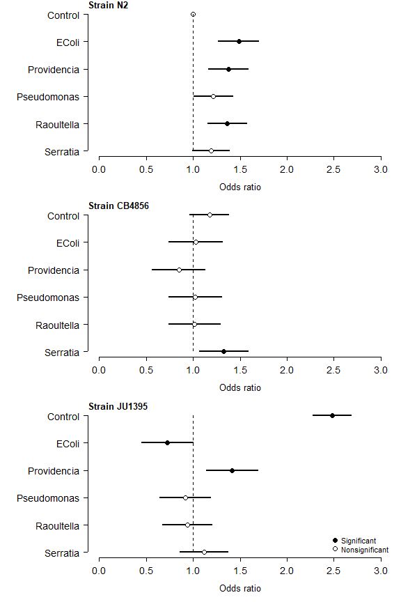

```r
use.y <- length(treats):1
strains <- as.character(unique(res$strain))
res$col <- ifelse(res$sig == 1, "black", "white")

par(mfrow=c(3, 1), mar=c(5, 10, 1,1), bty="n",
    las=1, lend=1, cex.lab=1.2, cex.axis=1.3)
for(i in 1:length(strains)){
    flag <- which(res$strain == strains[i])
    plot(res$or[flag], use.y, type="n",
         xlab="Odds ratio", yaxt="n",
         xlim=c(0, 3), ylab="")
    axis(side=2, at=use.y, labels=treats)
    segments(res$lo[flag], use.y,
             res$up[flag], use.y, lwd=2)
    title(main=paste("Strain", strains[i]), adj=0)
    segments(1, 1, 1, length(treats), lty=2)
    points(res$or[flag], use.y, cex=1.5,
           pch=21, bg=res$col[flag])
}
legend("bottomright",
       legend=c("Significant", "Nonsignificant"),
       pch=21, pt.bg=c("black", "white"),
       pt.cex=1.5, bty="n")
```

Or even better, combine the three strains onto a single panel. You can adjust the *Y* coordinate offsets (`res$yoff`) and other inputs to fine-tune the plot.

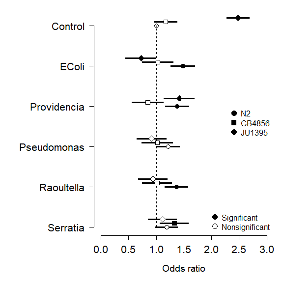

```r
shps <- 21:23
matchx <- match(res$strain, unique(res$strain))
res$shape <- shps[matchx]
res$yoff <- matchx-1
res$y <- use.y[match(res$trt, unique(res$trt))]
res$y <- res$y + res$yoff/10

par(mfrow=c(1, 1), mar=c(5, 10, 1,1), bty="n",
    las=1, lend=1, cex.lab=1.2, cex.axis=1.3)
plot(res$or, res$y, type="n",
    pch=res$shape, cex=1.3,
    bg=ifelse(res$sig == 1, "black", "white"),
    xlab="Odds ratio", yaxt="n",
    xlim=c(0, 3), ylab="")
segments(1, 1, 1, 6, lty=2)
segments(res$lo, res$y, res$up, res$y, lwd=3)
points(res$or, res$y,
    pch=res$shape, cex=1.3,
    bg=ifelse(res$sig == 1, "black", "white"))
axis(side=2, at=use.y, labels=unique(res$trt))

legend("bottomright",
       legend=c("Significant", "Nonsignificant"),
       pch=21, pt.bg=c("black", "white"),
       pt.cex=1.5, bty="n")
legend("right", legend=unique(res$strain),
       pch=shps, bty="n", pt.cex=1.5,
       pt.bg="black")
```

# 5 Area under the curve (AUC) and reciever operating characteristic (ROC)

Logistic regression is one way of solving what statisticians sometimes call a **classification problem**, where we want to use some set of predictor variables to classify observations into one category or another. The binary case is the simplest classification problem. The predictions of a logistic regression model will predict each observation to either be 0 or 1. We can use those predictions, and how often they are correct, to evaluate the efficacy of a logistic regression model.

First let’s define a function to get the predictions for a logistic regression model for its input data, with user-specified “cut-off” value that determines how great the predicted probability needs to be before declaring the prediction a 1 instead of a 0. The default, 0.5, means that any observation with a predicted probability >0.5 will be counted as 1.

```r
# function to get prediction:
pred.fun <- function(mod, data, res = "y",
                     pos = 1, neg = 0, cut = 0.5) {
    probs <- predict(mod, newdata = data, type = "response")
    ifelse(probs > cut, pos, neg)
}

# test it out:
p1 <- pred.fun(mlist[[4]])
ftable(p1~dat$y)
```

```
##       p1    0    1
## dat$y
## 0        7680 3007
## 1        4494 3890
```

This contingency table is called a **confusion matrix** and it summarizes how often the model is correct for a given cutoff value. Here, when the model predicts a success (y = 1), it is correct for 3890 out of (3890+3007) = 6897 observations. Confusion matrices are usually summarized by two measures, sensitivity and specificity.

$$Sensitivity=\frac{n(true\ positives)}{n(true\ positives)+n(false\ negatives)}$$

In our example, the sensitivity is 3890 / (3890 + 4494) = 0.463.

**Specificity** measures what proportion of failures (y = 0) were correctly identified. It is also called the **true negative rate**. It is calculated as:

$$Specificity=\frac{n(true\ negatives)}{n(true\ negatives)+n(false\ positives)}$$

In our example, the specificity was 7680 / (7680 + 3007) = 0.718.

The characteristics of the study system, the dataset, and the analysis can affect the sensitivity and the specificity of a model. If correctly identifying true positives is important (e.g., in disease screenings), then a model with greater sensitivity is preferred. If correctly identifying true negatives is important, then a model with greater specificity is preferred. The sensitivity and specificity can be varied by changing the threshold for 1 vs. 0.

A **receiver operating characteristic (ROC) curve** shows how sensitivity and specificity covary at different cut-off thresholds. We can construct an ROC curve by summarizing the confusion matrix at different cut-offs. The code below shows how to do this manually, so you can see for yourself how AUC is calculated. Afterwards, we’ll use functions from an add-on package to save some work.

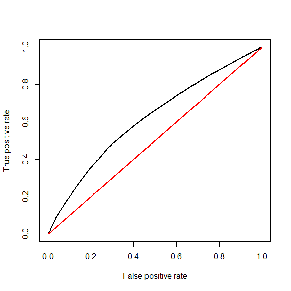

```r
# vector of cut offs to test
co <- seq(0, 1, by=0.01)

# vectors to hold specificity and sensitivity
sen <- spe <- numeric(length(co))

# calculate sensitivity and specificity in a loop
for(i in 1:length(co)){
    # predictions for current cutoff value
    pred <- pred.fun(mlist[[4]], cut=co[i])

    # rearrange to data frame
    con.mat <- data.frame(ftable(dat$y~pred))
    con.mat$pred <- as.numeric(as.character(con.mat$pred))
    con.mat$dat.y <- as.numeric(as.character(con.mat$dat.y))

    # special case: no predicted 1s
    if(! 1 %in% con.mat$pred){
        add.df <- data.frame(pred=1, dat.y=0:1, Freq=0)
        con.mat <- rbind(con.mat, add.df)
    }

    # special case: no predicted 0s
    if(! 0 %in% con.mat$pred){
        add.df <- data.frame(pred=0, dat.y=0:1, Freq=0)
        con.mat <- rbind(con.mat, add.df)
    }

    # sensitivity:
    tp <- which(con.mat$pred == 1 & con.mat$dat.y == 1)
    fn <- which(con.mat$pred == 0 & con.mat$dat.y == 1)
    sen[i] <- con.mat$Freq[tp] / (
                  con.mat$Freq[tp] + con.mat$Freq[fn])

    # specificity:
    tn <- which(con.mat$pred == 0 & con.mat$dat.y == 0)
    fp <- which(con.mat$pred == 1 & con.mat$dat.y == 0)
    spe[i] <- 1-con.mat$Freq[tn] /
                  (con.mat$Freq[tn] + con.mat$Freq[fp])
}

plot(spe, sen, type="l", lwd=2,
     xlim=c(0,1), ylim=c(0,1),
     xlab="False positive rate",
     yla="True positive rate")
segments(0, 0, 1, 1, col="red", lwd=2)
```

The diagonal red line shows the case of a model where predictions of 1 are just a likely to be true positives as false positives. Obviously, the curve for your model should fall above this line! The curve for a well-fitting model should increase quickly as false positive rate increases from 0, and reach a y value of 1 very quickly. A model that perfectly classifies observations should have an area under the curve (AUC) of 1 (can you see why?). A model that predicts an equal number of true positives and false positives has an AUC of 0.5. This represents a model that is no better than random chance at being correct, and is the “worst case scenario” for a classification model like logistic regression. We can approximate the AUC using rectangles:

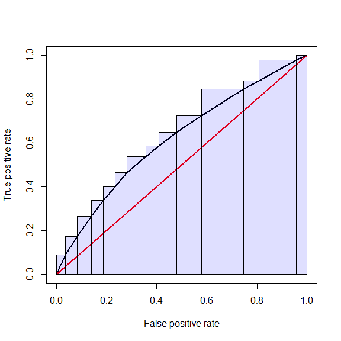

```r
plot(spe, sen, type="l", lwd=2,
     xlim=c(0,1), ylim=c(0,1),
     xlab="False positive rate",
     yla="True positive rate")
segments(0, 0, 1, 1, col="red", lwd=2)

# add to previous plot:
rect(spe[-length(spe)], 0,
     spe[-1], sen, border="black",
     col="#0000FF20")
```

And the numerical integration (lazy way):

```r
auc1 <- sum((diff(spe)*-1) * sen[-1])
auc2 <- sum((diff(spe)*-1) * sen[-length(sen)])
(auc1+auc2)/2
```

```
## [1] 0.6172765
```

The AUC of 0.617 is not too bad, but not great either. Remember that 0.5 is model no better than a coin flip, and 1 is perfect. As much fun as it is to manually calculate ROC curves and definite integrals, we can get the ROC and AUC much more quickly using the functions in package `pROC`.

```r
library(pROC)
```

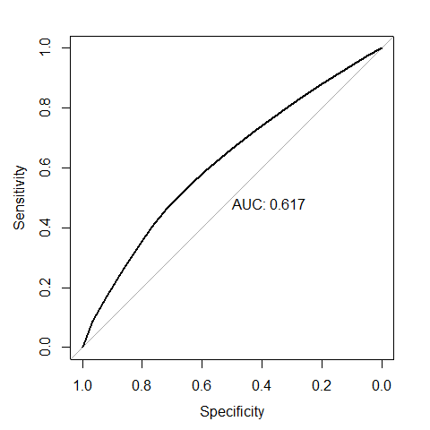

```r
# generate predictions (probabilities)
p1 <- predict(mlist[[4]], type="response")
roc1 <- roc(dat$y ~ p1, plot = TRUE, print.auc = TRUE)
```

```r
roc1
```

```
##
## Call:
## roc.formula(formula = dat$y ~ p1, plot = TRUE, print.auc = TRUE)
##
## Data: p1 in 10687 controls (dat$y 0) < 8384 cases (dat$y 1).
## Area under the curve: 0.6173
```

The AUC calculated by package `pROC` (0.6173) is close to the value we calculated by hand. If you don’t like the default figure produced by `roc()`, you can extract the sensitivity and sensitivity scores and make your own plot.

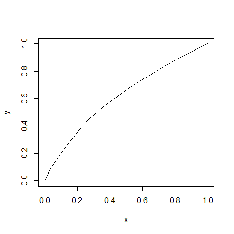

```r
# 1- to orient axis correct way:
x <- 1-roc1$specificities
y <- roc1$sensitivities
plot(x,y, type="l")
```

[**Go back to main page**](https://greenquanteco.github.io/index.html)

# 6 References

Bubrig, L. T., J. M. Sutton, and J. L. Fierst. 2020. [*Caenorhabditis elegans* dauers vary recovery in response to bacteria from natural habitat](https://doi.org/10.1002/ece3.6646). Ecology and Evolution 10:9886–9895.

# 7 Legal notice

This site is for educational purposes only. This work and its content is released under the [Creative Commons Attribution-ShareAlike 4.0](https://creativecommons.org/licenses/by-sa/4.0/) license. Inclusion of third-party data falls under guidelines of fair use as defined in [section 107 of the US Copyright Act of 1976](https://www.law.cornell.edu/uscode/text/17/107).

[^1]: I have never really figured out the syntax for how `mosaicplot()` splits the data (i.e, order of terms in the formula). Try different permutations of the formula until you get the plot you want :)